# Poisonous Mushroom Classification

Author

Amar Gill, Ruth Yankson, Limor Winter, Claire Saunders

Published

December 13, 2025

# 1 Summary

Here we attempt to build a classification model using a Support Vector Machine algorithm which can use physical characteristics of mushrooms to predict whether a North American mushroom from the Agaricus and Lepiota (Agaricaceae) family is edible or poisonous for human consumption. Our final classifier performed excellently on an unseen test data set, with precision of 1.00 and recall of 1.00 and an overall accuracy calculated to be 1.00. On the 2438 test data observations, the model correctly predicted all 2438. Although the model performs extremely well it has practical limitations, because it requires the correct identification of 20 different physical characteristics of a given mushroom in order for the corresponding prediction to be correct. We believe the model could be a powerful tool for preventing the misidentification of the Agaricus and Lepiota family of mushrooms, but further efforts to improve the practical implementation of the model for usage by the public would be very useful.

# 2 Introduction

The *Agaricus* and *Lepiota* (Agaricaceae) family of mushrooms, includes many of the common gilled mushrooms found and cultivated in urban and suburban North America (Lincoff 1981). The family includes the common cultivated mushroom (*Agaricus bisporus*), and some of the best edible mushrooms, but it also includes poisonous mushrooms and a few that are deadly (Lincoff 1981). These mushrooms are sometimes found in forests, but many grow on lawns, in the compost, or along roadsides and grassy areas where they are readily accessible for human consumption (Lincoff 1981). Accurate assessment of the edibility of these mushrooms is extremely important prior to consumption, however there is no simple rule for determining whether any example is poisonous or edible (Lincoff 1981).

Here we ask if we can use a supervised machine learning algorithm to predict whether a given mushroom from the Agaricus and Lepiota family of mushrooms is edible or poisonous, based upon its physical characteristics. Answering this question is important because mushroom poisonings are common and the greatest risk factor for mushroom poisoning is the misidentification of poisonous species as edible, in particular by amateur mushroom foragers and immigrants (Diaz 2016). If made accessible to the public in North America, accurate prediction of mushrooms in this family could prevent poisoning and support the safe consumption of common edible mushrooms.

# 3 Methods

## 3.1 Data

The data set used in this project includes hypothetical mushroom samples drawn from The Audubon Society Field Guide to North American Mushrooms by Gary Lincoff (Lincoff 1981). It was sourced from the UCI Machine Learning Repository (Dua and Graff 2017), specifically the file *agaricus-lepiota.data*. It includes 8124 descriptions of hypothetical mushroom samples that correspond to 23 species of mushrooms in the Agaricus and Lepiota Family (Lincoff 1981). Each row includes 22 categorical variables that are physical characteristics of the mushroom sample, including the odor, gill-spacing, gill-color, gill-size, population, habitat, etc, and is labelled as edible or poisonous.

## 3.2 Computing Environment

All analyses were performed in Python (Van Rossum and Drake 2009) using pandas (McKinney 2010), NumPy (Harris et al. 2020), and scikit-learn (Pedregosa et al. 2011) for data processing and modeling. Data validation employed Pandera (Bantilan 2020), and visualizations were generated using Altair (VanderPlas 2018). The dataset was accessed via the UCI Machine Learning Repository (Dua and Graff 2017). This report was written and rendered using Quarto (Posit Software, PBC 2025) to ensure full reproducibility.

# 4 Analysis

Table 1: First five rows of the raw dataset.

|  | class | cap_shape | cap_surface | cap_color | bruises | odor | gill_attachment | gill_spacing | gill_size | gill_color | ... | stalk_surface_below_ring | stalk_color_above_ring | stalk_color_below_ring | veil_type | veil_color | ring_number | ring_type | spore_print_color | population | habitat |
| --- | --- | --- | --- | --- | --- | --- | --- | --- | --- | --- | --- | --- | --- | --- | --- | --- | --- | --- | --- | --- | --- |
| 0 | p | x | s | n | t | p | f | c | n | k | ... | s | w | w | p | w | o | p | k | s | u |
| 1 | e | x | s | y | t | a | f | c | b | k | ... | s | w | w | p | w | o | p | n | n | g |
| 2 | e | b | s | w | t | l | f | c | b | n | ... | s | w | w | p | w | o | p | n | n | m |
| 3 | p | x | y | w | t | p | f | c | n | n | ... | s | w | w | p | w | o | p | k | s | u |
| 4 | e | x | s | g | f | n | f | w | b | k | ... | s | w | w | p | w | o | e | n | a | g |

5 rows × 23 columns

A preview of the first five rows of the raw dataset is shown in Table 1, which illustrates the categorical structure of all features prior to cleaning.

## 4.1 Interpretation of Outlier / Anomalous Value Checks

All features in this dataset are categorical, so traditional numeric outlier checks (e.g., detecting extreme continuous values) do not apply. Instead, the relevant “anomalous values” for categorical data are unexpected or invalid category levels.

We addressed this by validating every categorical column against the official list of allowed levels from the UCI dataset documentation. Since all observed category values matched their expected sets, we conclude that no anomalous values are present in this dataset.

# 5 Data Splitting

We aim to classify mushrooms as edible (0) or poisonous (1). Because the dataset contains roughly equal proportions of edible and poisonous samples, we apply a 70/30 train–test split to ensure sufficient data for both model training and evaluation. To maintain consistency and reproducibility across runs, a random state of 123 is set when performing the split, allowing subsequent users to obtain identical training and test sets.

# 6 EDA After Data Splitting

Table 2: First five rows of the cleaned dataset.

|  | cap_shape | cap_surface | cap_color | bruises | odor | gill_attachment | gill_spacing | gill_size | gill_color | stalk_shape | ... | stalk_surface_below_ring | stalk_color_above_ring | stalk_color_below_ring | veil_color | ring_number | ring_type | spore_print_color | population | habitat | is_poisonous |
| --- | --- | --- | --- | --- | --- | --- | --- | --- | --- | --- | --- | --- | --- | --- | --- | --- | --- | --- | --- | --- | --- |
| 0 | f | s | g | f | n | f | w | b | h | t | ... | s | w | w | w | o | e | k | s | g | 0 |
| 1 | x | s | n | f | f | f | c | n | b | t | ... | k | p | p | w | o | e | w | v | d | 1 |
| 2 | x | y | y | f | f | f | c | b | g | e | ... | k | b | n | w | o | l | h | y | p | 1 |
| 3 | x | f | y | f | f | f | c | b | p | e | ... | k | b | n | w | o | l | h | v | g | 1 |
| 4 | x | f | g | f | f | f | c | b | g | e | ... | k | n | b | w | o | l | h | v | g | 1 |

5 rows × 21 columns

A preview of the first five rows of the training dataset is shown in Table 2, which illustrates the categorical structure of all features after cleaning and splitting.

Table 3: Summary of mushroom feature characteristics

| # | feature | n_categories | most_frequent_category | most_frequent_count |
| --- | --- | --- | --- | --- |
| 1 | gill_color | 12 | b | 1202 |
| 2 | cap_color | 10 | n | 1567 |
| 3 | odor | 9 | n | 2439 |
| 4 | spore_print_color | 9 | w | 1655 |
| 5 | stalk_color_below_ring | 9 | w | 3071 |
| 6 | stalk_color_above_ring | 9 | w | 3131 |
| 7 | habitat | 7 | d | 2195 |
| 8 | population | 6 | v | 2813 |
| 9 | cap_shape | 6 | x | 2534 |
| 10 | ring_type | 5 | p | 2778 |
| 11 | cap_surface | 4 | y | 2291 |
| 12 | stalk_surface_below_ring | 4 | s | 3434 |
| 13 | veil_color | 4 | w | 5542 |
| 14 | stalk_surface_above_ring | 4 | s | 3630 |
| 15 | ring_number | 3 | o | 5246 |
| 16 | stalk_shape | 2 | t | 3211 |
| 17 | gill_size | 2 | b | 3939 |
| 18 | gill_spacing | 2 | c | 4766 |
| 19 | gill_attachment | 2 | f | 5534 |
| 20 | bruises | 2 | f | 3330 |

We summarize all 20 categorical predictors in Table 3, which reports the number of levels and the dominant category for each feature. Given that `veil_type` only has one level, it dropped because it contains only a single category for all observations. A feature with no variation cannot help the model distinguish edible from poisonous mushrooms, provides no predictive signal, and only adds redundant columns after one-hot encoding. Therefore, it is removed to simplify the feature set and prevent unnecessary model complexity.

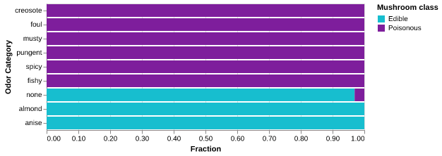

Figure 1: Class Proportions (edible vs poisonous) by Odor

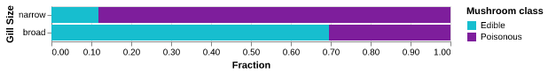

Figure 2: Class Proportions (edible vs poisonous) by Gill Size

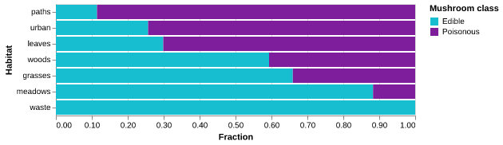

Figure 3: Class Proportions (edible vs poisonous) by Habitat

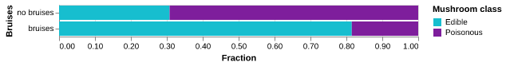

Figure 4: Class Proportions (edible vs poisonous) by Bruises

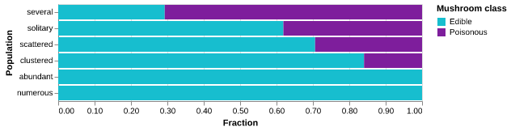

Figure 5: Class Proportions (edible vs poisonous) by Population Type

### 6.0.1 Relationship Between Physical Features and Toxicity: An Exploratory Overview

Table 4: Ranking of features by how well they distinguish poisonous mushrooms

| # | feature | poison_variance |
| --- | --- | --- |
| 1 | odor | 0.22 |
| 2 | stalk_color_above_ring | 0.19 |
| 3 | stalk_color_below_ring | 0.19 |
| 4 | spore_print_color | 0.17 |
| 5 | ring_type | 0.17 |
| 6 | veil_color | 0.17 |
| 7 | ring_number | 0.13 |
| 8 | gill_color | 0.13 |
| 9 | cap_shape | 0.12 |
| 10 | habitat | 0.1 |
| 11 | stalk_surface_below_ring | 0.09 |
| 12 | gill_size | 0.08 |
| 13 | stalk_surface_above_ring | 0.08 |
| 14 | cap_surface | 0.06 |
| 15 | gill_spacing | 0.06 |
| 16 | bruises | 0.06 |
| 17 | population | 0.06 |
| 18 | cap_color | 0.05 |
| 19 | gill_attachment | 0.04 |
| 20 | stalk_shape | 0 |

A ranking of features by their discriminatory power is shown in Table 4, using the variance in poisonous fraction across categories as an association measure.

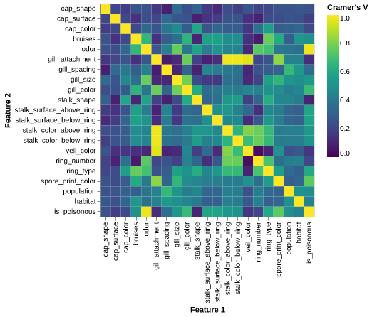

Figure 6: Correlation heatmap (Cramer’s V) for all feature and feature-target pairs in the training data.

## 6.1 Summary of Anomalous Correlation Between Features:

Figure 6 shows a high correlation between the feature `gill_attachment` and the three features `stalk_color_above_ring`, `stalk_color_below_ring`, and `veil_color`. We expect this is a feature of the dataset because it includes a high number of observations (5686 in our training data) and only 23 species, so there are many repeated instances of each species. If a particular species has fixed color and gill attachment characteristics then it is expected that we would find a high correlation between these features. It is not likely to be a sign of data leakage, but does suggest that there are weaknesses in the biological representativeness of the dataset. Therefore, the dataset may not be the strongest choice for generalizing predictions about the poisonousness of mushrooms across the full Agaricus and Lepiota (Agaricaceae) family, since it may not capture the true diversity and independence of these features found in nature.

## 6.2 Summary of Anomalous Correlation Between Feature “Odor” and Target:

Figure 6 shows a high correlation between the feature `odor` and the target, and a moderately high correlation between `spore_print_color` and the target. However, the dataset we are using includes background information on the logical rules discovered by prior researchers Duch, Adamczak, and Grabczewski (Duch, Adamczak, and Grabczewski 1996), and they found that “odor” is often the first split for identifying poisonous mushrooms, and “spore_print_color” is often the second. Hence both of these features are expected to be strong predictors of the target and the seeming anomalous correlation is simply an accurate reflection of biological reality as captured by the dataset, and not likely to be a sign of data leakage in this case.

# 7 Model

In our classification problem, we opt to use `SVC` (Buitinck et al. 2013) as our model of choice for its effective usage in this scenario. We do not have an extreme amount of data (< 10000 observations) on top of only being a binary classification task.

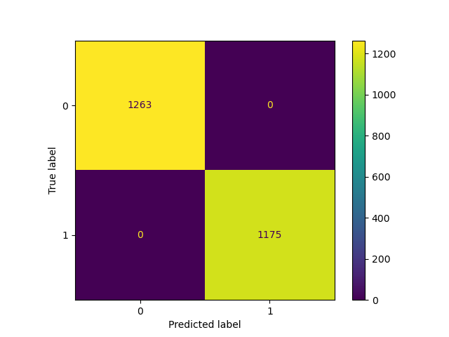

Figure 7

Confusion matrix for the SVC classifier on the test set.

# 8 Results & Discussion

Our prediction model performed excellently on test data, classifying all of the mushroom examples correctly as poisonous or edible, with an accuracy of 1.00. Given that our model predicted perfectly, no optimization was required. As shown in Figure 7, the SVC correctly classified every mushroom in the test set, yielding no false positives or false negatives.

Hence, if an amateur mushroom enthusiast aimed to utilize the model to predict edibility but misidentified the physical characteristics of the mushroom they were attempting to classify, then the accuracy of the models predictions would be effectively moot as it would not be returning a prediction for the true foraged mushroom. For future work, one could consider creating a similar predictor with a smaller number of features to increase the practical efficacy of the model, though they would need to consider balancing the models accuracy with efficacy, because the risk of falsely predicting a mushroom as edible could be fatal. It is also worth noting that the hypothetical mushroom observations in this model are based upon a book from 1981 (Lincoff 1981), so it would be wise to consider whether the data could be updated to be sourced from a more recent source of mushroom science. Or, for more robust and reliable deployment, future work on similar classification models could be elevated by focussing on a dataset that is not hypothetical but instead a true collection of mushroom observations. With true observations, the test scores could be considered more reliable, and may have greater generalizability to new true examples.

## 9 References

Bantilan, Niels. 2020. *Pandera: Statistical Data Validation for Pandas*. https://pandera.readthedocs.io/.

Buitinck, L., G. Louppe, M. Blondel, F. Pedregosa, A. Mueller, O. Grisel, and G. Varoquaux. 2013. “API Design for Machine Learning Software: Experiences from the Scikit-Learn Project.” In *ECML PKDD Workshop: Languages for Data Mining and Machine Learning*, 108–22.

Diaz, James H. 2016. “Mistaken Mushroom Poisonings.” *Wilderness & Environmental Medicine* 27 (2): 330–35.

Dua, Dheeru, and Casey Graff. 2017. “UCI Machine Learning Repository: Mushroom Data Set.” University of California, Irvine, School of Information; Computer Sciences. https://archive.ics.uci.edu/dataset/73/mushroom.

Duch, W., R. Adamczak, and K. Grabczewski. 1996. “Extraction of Logical Rules from Training Data Using Backpropagation Networks.” In *Proceedings of the 1st Online Workshop on Soft Computing*, 25–30.

Harris, Charles R., K. Jarrod Millman, Stéfan J. van der Walt, Ralf Gommers, Pauli Virtanen, David Cournapeau, et al. 2020. “Array programming with NumPy.” *Nature* 585 (7825): 357–62. https://doi.org/10.1038/s41586-020-2649-2.

Lincoff, Gary H. 1981. *The Audubon Society Field Guide to North American Mushrooms*. New York: Alfred A. Knopf.

McKinney, Wes. 2010. “Data Structures for Statistical Computing in Python.” In *Proceedings of the 9th Python in Science Conference*, edited by Stéfan van der Walt and Jarrod Millman, 51–56.

“Mushroom.” 1981. https://doi.org/10.24432/C5959T.

Pedregosa, Fabian, Gaël Varoquaux, Alexandre Gramfort, Vincent Michel, Bertrand Thirion, Olivier Grisel, Mathieu Blondel, et al. 2011. “Scikit-learn: Machine Learning in Python.” *Journal of Machine Learning Research* 12: 2825–30.

Posit Software, PBC. 2025. *Quarto: Scientific and Technical Publishing System*. https://quarto.org/.

Van Rossum, Guido, and Fred L. Drake. 2009. *Python 3 Reference Manual*. Scotts Valley, CA: CreateSpace.

VanderPlas, Jake. 2018. “Altair: Interactive Statistical Visualizations for Python.” *Journal of Open Source Software* 3 (32): 1057. https://doi.org/10.21105/joss.01057.